# Recursión y Backtracking

### Mauricio Oyarzún Silva, Estructura de Datos, 2020-01

## ¿Que es la Recursión?

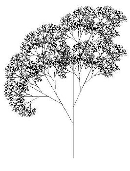

*La recursión es una forma de encontrar la solución de problemas basándose en la solución de un subconjunto del mismo problema.*

Algunos de estos problemas pueden ser resueltos habitualmente por medio de la iteración, sin embargo, esto requiere la capacidad o la posibilidad de encontrar el "índice" que determina esta iteración. La recursión no necesita conocer este orden, porque los pasos se generán por la repetición de llamadas de la misma función que trabaja sobre un subconjunto de los datos, hasta que una condición de parada es alcanzada.

### Recursividad y Computabilidad Universal

La mayoría de los lenguajes de computación admiten la recursividad. Incluso existen algunos lenguajes *funcionales* que solo admiten recursión y no iteración (como [Haskel](https://www.haskell.org/)). Ha sido probado que este tipo de lenguajes son *Turing Completos*.

> La *Turing completitud* hace referencia a aquellos lenguajes que pueden implementar cualquier máquina de Turing. También se le llama *Computabilidad Universal*

> Si no sabe quien es *Alan Turing*, el padre de la computación moderna, le recomiendo ver la película [The Imitation Game](https://www.imdb.com/title/tt2084970/).

### Problema de "call stack"

[figure not shown]

Uno de los principales problemas de la recursividad es el problema de *call stack*, que se produce cuando las llamadas sucesivas a la función recursiva van multiplicando el stack de entrada. Por ejemplo, si tenemos un vector, cada llamada recursiva tendrá una copia diferente de este vector (un nuevo *frame*), aumentando el uso de memoria.

> El *call stack* es una estructura de datos que se encarga de gestionar todos los elementos involucrados con las *rutinas/programas* que se ejecutan en un computador.

### Problema de "call stack"

[figure not shown]

Los lenguajes imperativos manejan este problema a través de las iteraciones, teniendo más problemas para manejarlo a través de recursión. Algunos lenguajes funcionales solucionan esto a través de una técnica llamada *tail call*.

> El *tail call* es un algoritmo a través del cual se crea un frame solo para la última llamada de la iteración permitiendo ahorrar memoria.

### Ejemplo. ¿Como maneja el *call stack* Python?

```python
def recursive_search(arreglo, inf, sup, busc):
    if inf > sup:
        return -1

    print("Memoria en la función: %d KB" %(process.memory_info().rss/1024))

    middle = int(inf + (sup-inf)/2)

    if busc > arreglo[middle]:
        return recursive_search(arreglo, middle+1, sup, busc)
    elif busc < arreglo[middle]:
        return recursive_search(arreglo,inf,middle-1, busc)
    else:
        return middle
```

### Ejemplo. ¿Como maneja el *call stack* Python?

```python
print("Memoria antes de ejecutar: %d KB" % (process.memory_info().rss/1024))
print (recursive_search(arreglo,0,len(arreglo)-1, 20))
print("Memoria despues de ejecutar: %d KB" % (process.memory_info().rss/1024))
```

```
Memoria antes de ejecutar: 47044 KB
Memoria en la función: 47044 KB
Memoria en la función: 47044 KB
Memoria en la función: 47044 KB
Memoria en la función: 47044 KB
Memoria en la función: 47048 KB
Memoria en la función: 47048 KB
Memoria en la función: 47048 KB
Memoria en la función: 47048 KB
Memoria en la función: 47048 KB
Memoria en la función: 47048 KB
Memoria en la función: 47048 KB
Memoria en la función: 47048 KB
10
Memoria despues de ejecutar: 47048 KB
```

### Estructura de una función recursiva

Una función recursiva tiene 1 o más casos base, un caso base es aquel que se resuelve trivialmente sin tener que recurrir a llamar la función nuevamente.

> Por ejemplo, el cálculo del número factorial se puede resolver de manera recursiva: $$5!=4!*5=3!*4*5=2!*3*4*5=1!*2*3*4*5=1*2*3*4*5$$ En este caso, nuestro caso base es $1!$, pues su valor ya es previamente conocido.

Además, una función recursiva tiene uno o más casos recursivos que llaman a la función alternado los parametros de entrada. En el ejemplo del cálculo del número factorial, cada vez que decrementamos el número, es una nueva llamada recursiva.

### Estructuras de datos recursivas

[figure not shown]

Una estructura de datos recursiva, es aquella estructura que esta definida en función de si misma. Veamos un ejemplo con una clase simple. Si tenemos la `clase Empleado`, y nombramos a cargo a un supervisor, este supervisor es tan empleado como el resto, pero además ostenta una *jefatura*. De esta misma forma, veremos más adelante en este curso estructuras de datos que estan definidas en función de si mismas, como por ejemplo la **lista enlazada**, donde cada nodo tiene un valor y *apunta* al siguiente, que es una clase del mismo tipo.

### Recursividad simple vs múltiple

La *recursividad simple* es aquella que tiene solo un caso recursivo. Por ejemplo el cálculo del número `factorial`:

```python
def factorial(n):
    if(n==1):
        return 1

    return n*factorial(n-1)
```

### Recursividad simple vs múltiple

La *recursividad múltiple* es aquella que tiene más de un caso recursivo. Ejemplo de esto vimos al principio de este *notebook* con la función `recursive_search()` , esta función en realidad se llama búsqueda binaria y es uno de los mejores algoritmos para buscar en arreglos ordenados.

```python
def binary_search(arreglo, inf, sup, busc):
    if inf > sup:
        return -1

    middle = int(inf + (sup-inf)/2)

    if busc > arreglo[middle]:
        return recursive_search(arreglo, middle+1, sup, busc)
    elif busc < arreglo[middle]:
        return recursive_search(arreglo,inf,middle-1, busc)
    else:
        return middle
```

### Recursividad indirecta

Hasta el momento, hemos visto solo ejemplos de recursión directa, es decir, funciones que se llaman a sí mismas de forma directa. La recursividad indirecta implica dos o más funciones cíclicas que se llaman entre sí recursivamente. Como ejemplo, veremos el recorrido de una matriz a través de recursividad indirecta.

```python
def llenado_fila(mat, i):
    if(i == 10):
        return mat

    return llenado_columna(mat, i, 0)

def llenado_columna(mat, i, j):
    if(j == 10):
        return llenado_fila(mat, i+1)

    print((i*10) + j)
    mat[i][j] = (i*10) + j
    return llenado_columna(mat, i, j+1)
```

### Estructura de una función recursiva

[figure not shown]

En general, podemos decir que la estructura de una función recursiva es:

- Establecer la o las condiciones de borde o término.
- Realizar el computo del cuerpo de la función.
- Establecer la o las condiciones de llamada recursiva.

## Backtracking

[figure not shown]

Los métodos de *Backtracking* buscan resolver problemas a través de la búsqueda de todas las soluciones de un problema que satisfagan ciertas restricciones. Esta forma de resolver problemas esta asociada regularmente a estructuras del tipo árbol o grafo, por lo que tambien se encuentra relacionada a la recursividad.

### Bactracking (cont.)

Este tipo de métodos nacen para evitar la búsqueda por *fuerza bruta* en aquellos problemas que puedan establecer de forma clara las restricciones, si no es posible establecerlas, su peor caso es comportarse como un algoritmo de *fuerza bruta*. Por este motivo, puede ser considerado un algoritmo de *terminación temprana*.

> Los algoritmos de *fuerza bruta* son aquellos que exploran todas las posibles soluciones sin discriminar en la efectividad del método ni en las respuestas obtenidas.

> Un algoritmo de *terminación temprana* es un tipo de mejora a cualquier algoritmo que pueda evitar realizar trabajo innecesario a partir de estados que es imposible alcanzar.

### Ejemplo de Backtracking: 8 Puzzle

[figure not shown]

El problema del *8 puzzle* es un ejemplo de problemática susceptible a ser resuelta con *Backtracking*, en el tenemos un tablero separado en 9 espacios, de los cuales 8 están ocupados con fichas numeradas del 1 al 8. Existe un espacio vacio al cual una ficha puede moverse siempre que esta sea contigua ya sea vertical u horizontalmente, la restricción en este problema viene dado por la imposibilidad de fichas no contiguas al espacio vacio de moverse a el. El objetivo del juego es dejar la secuencia ordenada de menor a mayor.

#### Ejemplo de Backtracking: 8 Puzzle (cont.)

[figure not shown]

Al limitar los posibles estados eliminando aquellos que no pueden ser alcanzados, el espacio de búsqueda disminuye considerablemente, acelerando el algoritmo. En la figura podemos ver el espacio de solución para los estados alcanzables.